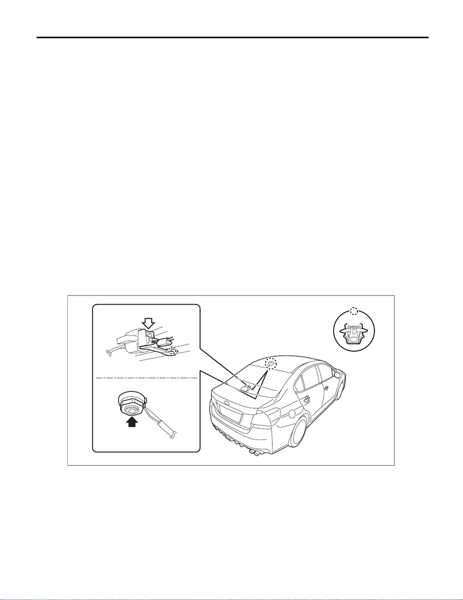

ET-14

Antenna

ENTERTAINMENT

10.Antenna

A: REMOVAL

1. ANTENNA

1) Disconnect the ground cable from battery and wait for at least 60 seconds before starting work. <Ref. to

NT-5, BATTERY, NOTE, Note.>

NOTE:

For models other than STI model, disconnect the ground terminal from battery sensor.

2) Lower the trim panel - roof assembly. <Ref. to EI-99, REMOVAL, Roof Trim.>

NOTE:

Procedures for the trim panel - roof assembly is performed inside the vehicle. Therefore, remove the follow-

ing parts.

• Rear seat cushion assembly

• Lower inner trim

• Upper inner trim

• Trim panel - rear pillar UPR

• Light assembly - map

• Sun visor ASSY

• Light assembly - room

• Assist rail

• Garnish - roof (model with sunroof)

• Trim panel - roof assembly

3) Remove the antenna.

(1) Disconnect the connector and release the connector clip.

(2) Remove the nut and detach the antenna.

2. ANTENNA FEEDER CORD

1) Disconnect the ground cable from battery and wait for at least 60 seconds before starting work. <Ref. to

NT-5, BATTERY, NOTE, Note.>

NOTE:

For models other than STI model, disconnect the ground terminal from battery sensor.

2) Lower the trim panel - roof assembly in the same manner as the removal procedure of antenna.

3) Remove the cord assembly - antenna feeder.

ET-00911

[figure not shown]

ET-15

Antenna

ENTERTAINMENT

B: INSTALLATION

1. ANTENNA

1) Install the antenna.

Tightening torque:

4.5 N·m (0.5 kgf-m, 3.3 ft-lb)

2) Install the trim panel - roof assembly. <Ref. to EI-102, INSTALLATION, Roof Trim.>

3) Connect the battery ground terminal. <Ref. to NT-5, BATTERY, NOTE, Note.>

NOTE:

For models other than STI model, connect the ground terminal to battery sensor.

2. ANTENNA FEEDER CORD

1) Install the cord assembly - antenna feeder and the trim panel - roof assembly. <Ref. to EI-102, INSTAL-

LATION, Roof Trim.>

2) Connect the battery ground terminal. <Ref. to NT-5, BATTERY, NOTE, Note.>

NOTE:

For models other than STI model, connect the ground terminal to battery sensor.